**Compact reference report:** Links remain active for bundled outputs and tracked workflow source files. Dotted labels identify runtime tools or reproducible files intentionally omitted from the compact bundle. Run `Rscript example/run_example.R` to recreate the complete local output tree under `example/run_results/`.

# Step 6: Phylogenetic Tree Construction

# 1 Introduction

## 1.1 Purpose

This notebook is **Step 6** of the 16S rRNA sequencing data processing pipeline. Like [Step 7](https://github.com/changlabs/DADA2_16S_Illumina_PairedEnd_Workflow/blob/main/R/notebooks/7_copy_number_correction.md), it branches directly from [Step 5](https://github.com/changlabs/DADA2_16S_Illumina_PairedEnd_Workflow/blob/main/R/notebooks/5_dada2_pipeline.md) and is independent of the copy-number-correction branch. [Step 8](https://github.com/changlabs/DADA2_16S_Illumina_PairedEnd_Workflow/blob/main/R/notebooks/8_microbial_load_correction.md) does not branch directly from Step 5; it follows Step 7 because it requires Step 7’s copy-number-corrected abundance table. This notebook constructs a phylogenetic tree from the ASV sequences generated in Step 5: sequences are first aligned with [DECIPHER](https://www2.decipher.codes/)’s profile-to-profile multiple sequence alignment algorithm, then used to infer an approximately-maximum-likelihood tree with [FastTree](https://morgannprice.github.io/fasttree/) under the GTR+CAT substitution model.

This step is optional in the sense that [Step 9 (Phyloseq Object)](https://github.com/changlabs/DADA2_16S_Illumina_PairedEnd_Workflow/blob/main/R/notebooks/9_phyloseq_object.md) runs without it, falling back gracefully if no tree is found – but it is a prerequisite for any downstream analysis that incorporates evolutionary relationships between ASVs. Phylogenetic trees are important for microbiome analyses because:

- **UniFrac distances**: Weighted and unweighted [UniFrac](https://doi.org/10.1128/AEM.71.12.8228-8235.2005) metrics require phylogenetic information to calculate community dissimilarity based on evolutionary relationships.
- **Phylogenetic diversity (PD)**: Faith’s PD and other phylogenetic alpha diversity metrics measure the total branch length represented in a community.
- **Evolutionary context**: Understanding how ASVs are related helps interpret ecological patterns and identify taxonomic groups.
- **Comparative analyses**: Phylogenetic placement allows comparison with reference sequences.

## 1.2 Prerequisites

Before running this notebook, ensure that:

1. **Step 5 (DADA2 Pipeline)** has been completed successfully.
2. The ASV sequences file asv_sequences.csv is present in results/5_dada2_pipeline/.
3. The project-local **FastTree** executable is installed at tools/fasttree/FastTree by running setup/install_required_tools.R on Linux.
4. **[DECIPHER](https://www2.decipher.codes/)** package is installed from Bioconductor.

## 1.3 What This Notebook Does

The workflow accomplishes the following tasks:

1. **Load ASV Sequences**: Reads the ASV sequences generated by the DADA2 pipeline
2. **Multiple Sequence Alignment**: Aligns all ASV sequences using DECIPHER’s profile-to-profile alignment algorithm
3. **Phylogenetic Tree Construction**: Builds an approximately-maximum-likelihood tree with FastTree under the GTR+CAT model, validates its ASV tips, and midpoint-roots it
4. **Tree Export**: Saves the tree in Newick format (raw `ASV_ID` tip labels) for use in downstream analyses, plus a second, separately-labelled Newick file per available taxonomy database (`SILVA`/`GTDB`, tip labels replaced with `Unique_Tax`) for direct upload to [iTOL](https://itol.embl.de/)
5. **Static Tree Visualization**: Renders each database’s labelled tree as a rectangular (phylogram) PDF plot with a substitutions-per-site x-axis

## 1.4 Expected Input

- **Location**: ASV sequences results/5_dada2_pipeline/asv_sequences.csv and taxonomy tables from Step 5
- **Format**: CSV file with columns `ASV_ID` and `Sequence`

## 1.5 Expected Output

- Multiple sequence alignment in FASTA format (alignment.fasta)
- Phylogenetic tree in Newick format, `ASV_ID` tip labels (phylogenetic_tree.nwk)
- Phylogenetic tree in Newick format, `Unique_Tax` tip labels – one file per available taxonomy database (e.g. phylogenetic_tree_SILVA_labeled.nwk, phylogenetic_tree_GTDB_labeled.nwk) – ready to upload directly to [iTOL](https://itol.embl.de/) for interactive visualization and editing
- Static rectangular tree plots in PDF format, one per database (e.g. phylogenetic_tree_SILVA.pdf), plus branch_length_distribution.pdf
- Summary statistics Excel file (phylogenetic_tree_summary.xlsx)

# 2 Environment Setup

## 2.1 Load Required Packages

The chunk below loads every R package this notebook depends on – `Biostrings` and `DECIPHER` for sequence handling and alignment, `ape` for tree validation, export, statistics and visualization, and `phangorn` for midpoint rooting – plus the shared reporting helpers sourced from R/functions. Interactive tree exploration and editing can be handled externally by uploading the Newick (`*.nwk`) files to [iTOL](https://itol.embl.de/) (see Visualize Interactively with iTOL below).

```r
# Biostrings: Biological string manipulation (Bioconductor)
# Provides functions for handling DNA/RNA sequences
library(Biostrings)

# DECIPHER: Tools for curating, analyzing, and manipulating biological sequences
# Used for multiple sequence alignment with profile-to-profile algorithm
library(DECIPHER)

# data.table: High-performance data manipulation
# Provides fast operations for handling large data tables
library(data.table)

# DT: Interactive tables in R Markdown
# Creates searchable, sortable HTML tables
library(DT)

# fs: Cross-platform filesystem operations
# Consistent functions for file and directory manipulation
library(fs)

# ggplot2: Grammar of graphics plotting
# Used for creating publication-quality visualizations
library(ggplot2)

# here: Project-relative file paths
# Enables reproducible path construction regardless of working directory
library(here)

# openxlsx: Excel file creation and manipulation
# Read and write Excel files without Java dependencies
library(openxlsx)

# parallel: Parallel processing support
# Built-in R package for multi-core processing
library(parallel)

# phangorn: Phylogenetic analysis and midpoint rooting
library(phangorn)

# ape: Core phylogenetic-tree validation, export, statistics, and plotting
library(ape)

# Source our custom Excel utility function from the project's function library
# This function handles creating or appending sheets to Excel workbooks
source(here("R", "functions", "add_sheet_to_excel_function.R"))

# Source our custom column dictionary utility function from the project's function library
# This function documents every exported column as a Sheet/Column/Explanation table
source(here("R", "functions", "build_column_dictionary_function.R"))

# Source our custom output-links utility function from the project's function library
# This function renders clickable Markdown links to output files written by this notebook
source(here("R", "functions", "render_output_links_function.R"))

# Source the custom render_output_tree utility function from the project's
# function library. This function prints this notebook's entire output
# folder as a clickable directory tree (used in "Output File Summary" below),
# scanned live from disk at knit time so it always matches what was actually
# produced on this run.
source(here("R", "functions", "render_output_tree_function.R"))

# Keep alternate datasets (including the bundled tutorial example) isolated
# without changing the historical data/ and results/ defaults.
source(here("R", "functions", "workflow_paths_function.R"))
```

## 2.2 Helper Function: Transpose Summary Tables for Excel Export

The Alignment Quality Assessment, Tree Statistics, and Results Summary sections below each build a long, one-row-per-metric summary table for readable on-screen display, then transpose it to a single wide row – one column per metric – before writing it to the Excel workbook, so every metric becomes its own individually documented column in the `Column_Dictionary` sheet rather than two generic “Metric”/“Value” columns. The function below centralizes that transpose-and-clean logic in one place, since it is used identically by all three sections.

```r
# Transpose a Long Metric/Value Table to a Wide, Type-Cleaned, Excel-Safe Row
#
# Arguments:
#   - metric_names : Character vector of metric/step names, in display order
#                     (e.g. alignment_stats$Metric).
#   - values       : Vector of corresponding values, in the same order (e.g.
#                     alignment_stats$Value). Typically already character,
#                     since a mix of numeric and text summary values (such as
#                     "245 - 250" length ranges alongside plain counts) forces
#                     R's c() to coerce the whole vector to character when the
#                     long table is first built.
#
# setNames() pairs each value with its metric name; t() flips that named
# vector into a 1-row matrix whose column names are exactly those metric
# strings; check.names = FALSE keeps them exactly as written (e.g. preserving
# the parentheses and "%" in "Mean gap percentage (%)") instead of R's
# default make.names() mangling.
#
# t() itself always returns a character matrix (a single R vector cannot mix
# types), which is what previously made openxlsx write every cell as text --
# triggering Excel's "Number Stored as Text" warning on every purely numeric
# cell. type.convert(as.is = TRUE) is applied column-by-column afterwards to
# convert each column back to its natural type (numeric/integer) whenever its
# single value parses cleanly as a number, while genuinely textual columns
# (e.g. "245 - 250" ranges, "Yes"/"No", "1.23 min") are left as character,
# since they were never numbers to begin with -- so the resulting Excel cells
# are typed correctly and no longer flagged.
transpose_metrics_to_wide <- function(metric_names, values) {

    wide_row <- as.data.frame(
        t(setNames(values, metric_names)),
        stringsAsFactors = FALSE,
        check.names = FALSE
    )

    as.data.frame(
        lapply(wide_row, type.convert, as.is = TRUE),
        stringsAsFactors = FALSE,
        check.names = FALSE
    )
}
```

# 3 Configuration

## 3.1 Define Path Parameters

Set up the input and output directory paths. Using `here()` ensures paths are relative to the [project root](https://github.com/changlabs/DADA2_16S_Illumina_PairedEnd_Workflow/tree/main/example), making the script portable across different systems.

```r
# Input folder containing DADA2 pipeline results
# This should contain the asv_sequences.csv file from Step 5
dada2_results_folder <- workflow_results_dir("5_dada2_pipeline")

# Base results folder for all pipeline outputs
results_folder <- workflow_results_dir()

# Specific output folder for this step (Step 6: Phylogenetic Tree)
# Numbered prefix maintains pipeline organization
output_folder <- here(results_folder, "6_phylogenetic_tree")

# Create the output directory if it does not already exist
if (dir_exists(output_folder)) {
    message("The existing output directory located at ", output_folder,
            "\nwill be used for this step.")
} else {
    cat("Creating new output directory in", output_folder, "\n")
    dir_create(output_folder, recurse = TRUE)
}
```

```
## The existing output directory located at PROJECT_ROOT/example/run_results/6_phylogenetic_tree
## will be used for this step.
```

```r
# Subdirectory for validated stage checkpoints
checkpoints_folder <- here(output_folder, "checkpoints")
dir_create(checkpoints_folder, recurse = TRUE)

# Whole-workspace checkpoints from older notebook versions cannot be
# validated safely and are not compatible with the resumable RDS format.
legacy_checkpoints <- here(
    checkpoints_folder,
    c("checkpoint_1_alignment.RData", "checkpoint_2_tree.RData", "checkpoint_final.RData")
)
legacy_checkpoints <- legacy_checkpoints[file_exists(legacy_checkpoints)]
if (length(legacy_checkpoints)) file_delete(legacy_checkpoints)

# Output Excel filename for summary statistics
output_excel_filename <- "phylogenetic_tree_summary.xlsx"

# Construct the full path to the output Excel file
output_excel_path <- here(output_folder, output_excel_filename)

# Display configuration
cat("Path Configuration:\n",
    "- Input folder:", dada2_results_folder, "\n",
    "- Output folder:", output_folder, "\n")
```

```
## Path Configuration:
##  - Input folder: PROJECT_ROOT/example/run_results/5_dada2_pipeline
##  - Output folder: PROJECT_ROOT/example/run_results/6_phylogenetic_tree
```

## 3.2 Define Processing Parameters

Configure parameters for parallel processing and tree construction.

```r
# Determine the number of CPU threads for parallel processing
# Reserve 2 cores for system operations to maintain responsiveness
# Use at least 1 thread even on single-core systems
detected_cores <- suppressWarnings(detectCores())
available_cores <- if (length(detected_cores) == 1L && is.finite(detected_cores) && detected_cores >= 1) as.integer(detected_cores) else 1L
nr_threads <- max(1L, available_cores - 2L)

# Set non-random seed for reproducibility
set.seed(42)

# Display configuration
cat("Processing Configuration:\n",
    "- Available CPU cores:", available_cores, "\n",
    "- Threads for alignment:", nr_threads, "\n",
    "- Random seed:", 42, "\n")
```

```
## Processing Configuration:
##  - Available CPU cores: 1
##  - Threads for alignment: 1
##  - Random seed: 42
```

## 3.3 Define FastTreeMP Path

Configure the path to the FastTreeMP executable.

```r
# Path to FastTree executable
# Installed by install_required_tools.R — compiled from source into tools/fasttree/
fasttree_path <- here("tools", "fasttree", "FastTree")

# Step 6 intentionally uses only the project-local executable installed by
# install_required_tools.R. This keeps the FastTree build/version under the
# workflow's control rather than silently selecting a system installation.
if (file_exists(fasttree_path) && file.access(fasttree_path, mode = 1) == 0) {
    cat("Project-local FastTree found at:", fasttree_path, "\n")
    fasttree_available <- TRUE
} else {
    stop(
        "The project-local FastTree executable is missing or not executable: ",
        fasttree_path, "\nRun setup/install_required_tools.R on Linux, then rerun Step 6."
    )
}
```

```
## Project-local FastTree found at: PROJECT_ROOT/tools/fasttree/FastTree
```

# 4 Load ASV Sequences

## 4.1 Read ASV Sequence File

Load the ASV sequences generated by the DADA2 pipeline in Step 5.

```r
# Path to ASV sequences file
asv_sequences_path <- here(dada2_results_folder, "asv_sequences.csv")

# Verify file exists
if (!file_exists(asv_sequences_path)) {
    stop("ASV sequences file not found: ", asv_sequences_path,
         "\nPlease ensure Step 5 (DADA2 Pipeline) has been completed.")
}

# Read ASV sequences
asv_sequences <- read.csv(asv_sequences_path, stringsAsFactors = FALSE)

required_asv_columns <- c("ASV_ID", "Sequence")
if (!all(required_asv_columns %in% names(asv_sequences))) {
    stop("ASV sequence file must contain columns ASV_ID and Sequence: ",
         asv_sequences_path)
}
if (nrow(asv_sequences) < 2L) {
    stop("At least two ASV sequences are required to construct a tree; found ",
         nrow(asv_sequences), ".")
}
if (anyNA(asv_sequences$ASV_ID) || any(asv_sequences$ASV_ID == "") ||
    anyDuplicated(asv_sequences$ASV_ID)) {
    stop("ASV_ID values must be non-missing and unique in: ", asv_sequences_path)
}
if (anyNA(asv_sequences$Sequence) || any(asv_sequences$Sequence == "") ||
    any(!grepl("^[ACGTRYSWKMBDHVN]+$", toupper(asv_sequences$Sequence)))) {
    stop("Sequence contains missing, empty, or non-IUPAC DNA values in: ",
         asv_sequences_path)
}

# A checkpoint is reusable only for this exact ASV file, tool build,
# processing configuration, and package stack.
pipeline_signature <- list(
    asv_file = path_norm(asv_sequences_path),
    asv_md5 = unname(tools::md5sum(asv_sequences_path)),
    fasttree_file = path_norm(fasttree_path),
    fasttree_md5 = unname(tools::md5sum(fasttree_path)),
    alignment = list(anchor = NA, processors = nr_threads),
    tree = list(model = "GTR+CAT", midpoint_root = TRUE),
    versions = c(
        DECIPHER = as.character(packageVersion("DECIPHER")),
        ape = as.character(packageVersion("ape")),
        phangorn = as.character(packageVersion("phangorn"))
    )
)

checkpoint_path <- function(stage) {
    here(checkpoints_folder, paste0("checkpoint_", stage, ".rds"))
}

load_stage_checkpoint <- function(stage, required_objects) {
    path <- checkpoint_path(stage)
    if (!file_exists(path)) return(NULL)
    checkpoint <- tryCatch(readRDS(path), error = function(e) {
        warning("Ignoring unreadable checkpoint ", basename(path), ": ",
                conditionMessage(e), call. = FALSE)
        NULL
    })
    if (is.null(checkpoint) || !identical(checkpoint$stage, stage) ||
        !identical(checkpoint$signature, pipeline_signature) ||
        !all(required_objects %in% names(checkpoint$objects))) {
        message("Ignoring incompatible checkpoint: ", basename(path))
        return(NULL)
    }
    message("Resuming from validated checkpoint: ", basename(path))
    checkpoint$objects
}

save_stage_checkpoint <- function(stage, objects) {
    path <- checkpoint_path(stage)
    temporary_path <- paste0(path, ".tmp")
    saveRDS(list(stage = stage, signature = pipeline_signature, objects = objects),
            temporary_path, compress = TRUE)
    if (file_exists(path)) file_delete(path)
    file_move(temporary_path, path)
    path
}

# Display summary
cat("ASV sequences loaded:\n",
    "- Total ASVs:", nrow(asv_sequences), "\n",
    "- Sequence length range:", min(nchar(asv_sequences$Sequence)), "-",
    max(nchar(asv_sequences$Sequence)), "bp\n",
    "- Mean sequence length:", round(mean(nchar(asv_sequences$Sequence)), 1), "bp\n")
```

```
## ASV sequences loaded:
##  - Total ASVs: 232
##  - Sequence length range: 251 - 255 bp
##  - Mean sequence length: 252.9 bp
```

|  | ASV_ID | Length | Sequence_Preview |
| --- | --- | --- | --- |
| 1 | ASV1 | 252 | TACGGAGGATGCGAGCGTTATCCGGATTTATTGGGTTTAAAGGGTGCGCA |
| 2 | ASV2 | 252 | TACGGAGGATGCGAGCGTTATCCGGATTTATTGGGTTTAAAGGGTGCGCA |
| 3 | ASV3 | 252 | TACGGAGGATGCGAGCGTTATCCGGATTTATTGGGTTTAAAGGGTGCGTA |
| 4 | ASV4 | 252 | TACGGAGGATGCGAGCGTTATCCGGATTTATTGGGTTTAAAGGGTGCGTA |
| 5 | ASV5 | 253 | TACGGAGGATCCGAGCGTTATCCGGATTTATTGGGTTTAAAGGGAGCGTA |
| 6 | ASV6 | 252 | TACGGAGGATGCGAGCGTTATCCGGATTTATTGGGTTTAAAGGGTGCGTA |
| 7 | ASV7 | 252 | TACGGAGGATGCGAGCGTTATCCGGATTTATTGGGTTTAAAGGGTGCGTA |
| 8 | ASV8 | 253 | TACGGAGGATTCAAGCGTTATCCGGATTTATTGGGTTTAAAGGGTGCGTA |
| 9 | ASV9 | 252 | TACGGAGGATGCGAGCGTTATCCGGATTTATTGGGTTTAAAGGGTGCGTA |
| 10 | ASV10 | 252 | TACGGAGGATGCGAGCGTTATCCGGATTTATTGGGTTTAAAGGGTGCGTA |

[output cut: 222 more lines]

## 4.2 Prepare Sequences for Alignment

Convert the ASV sequences to a DNAStringSet object for alignment.

```r
# Extract sequences and assign ASV IDs as names
sequences <- asv_sequences$Sequence

# Extract ASV-IDs from the sequence table (propagate to tip labels of the tree)
names(sequences) <- asv_sequences$ASV_ID

# Convert to DNAStringSet for DECIPHER
dna_stringset <- DNAStringSet(sequences)

# Display summary
cat("Prepared", length(dna_stringset), "sequences for alignment.\n")
```

```
## Prepared 232 sequences for alignment.
```

[output not shown]

# 5 Multiple Sequence Alignment

## 5.1 Perform Alignment with DECIPHER

Align all ASV sequences using DECIPHER’s profile-to-profile alignment algorithm. This method is particularly effective for aligning large numbers of sequences.

**Note**: Multiple sequence alignment can be computationally intensive for large datasets. The alignment uses parallel processing with the specified number of threads to accelerate computation.

```
## Resuming from validated checkpoint: checkpoint_1_alignment.rds
```

[output not shown]

```
## Alignment complete:
##  - Sequences aligned: 232
##  - Alignment length: 260 bp
##  - Processing time: 0.02 minutes
```

## 5.2 Export Alignment

Save the multiple sequence alignment to a FASTA file.

```
## Alignment saved to: PROJECT_ROOT/example/run_results/6_phylogenetic_tree/alignment.fasta
```

```
## Checkpoint saved: PROJECT_ROOT/example/run_results/6_phylogenetic_tree/checkpoints/checkpoint_1_alignment.rds
```

- Multiple sequence alignment (FASTA): example/run_results/6_phylogenetic_tree/alignment.fasta
- Tree checkpoint 1 (RDS, alignment): example/run_results/6_phylogenetic_tree/checkpoints/checkpoint_1_alignment.rds

## 5.3 Alignment Quality Assessment

Assess the quality of the multiple sequence alignment.

```r
# Calculate alignment statistics
alignment_width <- width(sequence_alignment)[1]
sequence_lengths <- width(dna_stringset)

# Calculate gap statistics
gap_counts <- sapply(as.character(sequence_alignment), function(x) {
    sum(strsplit(x, "")[[1]] == "-")
})

# Create alignment summary table
alignment_stats <- data.frame(
    Metric = c(
        "Number of sequences",
        "Original mean length (bp)",
        "Original length range (bp)",
        "Alignment length (bp)",
        "Mean gaps per sequence",
        "Gap range per sequence",
        "Mean gap percentage (%)"
    ),
    Value = c(
        length(sequence_alignment),
        round(mean(sequence_lengths), 1),
        paste(min(sequence_lengths), "-", max(sequence_lengths)),
        alignment_width,
        round(mean(gap_counts), 1),
        paste(min(gap_counts), "-", max(gap_counts)),
        round(mean(gap_counts) / alignment_width * 100, 2)
    ),
    stringsAsFactors = FALSE
)

# Display statistics -- kept in this long (one row per Metric) shape for the
# on-screen table below, which stays readable regardless of how many metrics
# there are; the Excel export just below transposes to one column per Metric
# instead (see comment there for why).
datatable(
    alignment_stats,
    options = list(pageLength = 10, dom = 't',
                    scrollY = "400px", scrollCollapse = TRUE, paging = FALSE),
    caption = "Multiple sequence alignment statistics"
)
```

|  | Metric | Value |
| --- | --- | --- |
| 1 | Number of sequences | 232 |
| 2 | Original mean length (bp) | 252.9 |
| 3 | Original length range (bp) | 251 - 255 |
| 4 | Alignment length (bp) | 260 |
| 5 | Mean gaps per sequence | 7.1 |
| 6 | Gap range per sequence | 5 - 9 |
| 7 | Mean gap percentage (%) | 2.75 |

```
## Sheet Alignment_Statistics added successfully to the workbook: PROJECT_ROOT/example/run_results/6_phylogenetic_tree/phylogenetic_tree_summary.xlsx
```

```
## Alignment statistics exported.
```

# 6 Phylogenetic Tree Construction

## 6.1 Build Tree with FastTreeMP

Construct an approximately-maximum-likelihood phylogenetic tree using the project-local FastTree executable with the GTR+CAT model, validate its complete ASV tip set and branch lengths, and midpoint-root it for downstream analyses that require an explicit root.

**About FastTreeMP**: FastTreeMP infers approximately-maximum-likelihood phylogenetic trees from alignments of nucleotide or protein sequences. It uses the Generalized Time-Reversible (GTR) model with CAT approximation for rate variation across sites, which is appropriate for 16S rRNA sequences.

```r
tree_output_path <- here(output_folder, "phylogenetic_tree.nwk")
fasttree_log_path <- here(output_folder, "fasttree.log")
tree_checkpoint_objects <- load_stage_checkpoint(
    "2_tree", c("phylo_tree", "tree_duration", "fasttree_log_lines")
)
```

```
## Resuming from validated checkpoint: checkpoint_2_tree.rds
```

```r
tree_checkpoint_loaded <- !is.null(tree_checkpoint_objects)

if (tree_checkpoint_loaded) {
    list2env(tree_checkpoint_objects, envir = environment())
    writeLines(fasttree_log_lines, fasttree_log_path)
} else {
    cat("Starting phylogenetic tree construction with project-local FastTree...\n")
    cat("Using the GTR+CAT model for nucleotide sequences.\n\n")
    tree_start_time <- Sys.time()
    temporary_tree_path <- paste0(tree_output_path, ".tmp")
    if (file_exists(temporary_tree_path)) file_delete(temporary_tree_path)

    # Quote the positional path explicitly so projects located below a
    # directory containing spaces or shell-sensitive characters remain valid.
    fasttree_args <- c("-nt", "-gtr", shQuote(alignment_output_path))

    previous_omp_threads <- Sys.getenv("OMP_NUM_THREADS", unset = NA_character_)
    Sys.setenv(OMP_NUM_THREADS = nr_threads)
    fasttree_status <- tryCatch(
        system2(
            fasttree_path,
            args = fasttree_args,
            stdout = temporary_tree_path,
            stderr = fasttree_log_path
        ),
        finally = {
            if (is.na(previous_omp_threads)) {
                Sys.unsetenv("OMP_NUM_THREADS")
            } else {
                Sys.setenv(OMP_NUM_THREADS = previous_omp_threads)
            }
        }
    )

    tree_end_time <- Sys.time()
    tree_duration <- difftime(tree_end_time, tree_start_time, units = "mins")
    if (!isTRUE(fasttree_status == 0) || !file_exists(temporary_tree_path) ||
        file_size(temporary_tree_path) == 0) {
        stop("FastTree failed or produced an empty tree (exit code ",
             fasttree_status, "). See: ", fasttree_log_path)
    }

    phylo_tree <- tryCatch(
        ape::read.tree(temporary_tree_path),
        error = function(e) stop("FastTree produced invalid Newick output: ",
                                 conditionMessage(e), "\nSee: ", fasttree_log_path)
    )
    if (anyDuplicated(phylo_tree$tip.label) ||
        !setequal(phylo_tree$tip.label, asv_sequences$ASV_ID)) {
        stop("FastTree tip labels do not exactly match the Step 5 ASV_ID set. See: ",
             fasttree_log_path)
    }
    if (is.null(phylo_tree$edge.length) || anyNA(phylo_tree$edge.length)) {
        stop("FastTree output has missing branch lengths. See: ", fasttree_log_path)
    }

    # FastTree infers an unrooted topology. Midpoint rooting supplies the
    # explicit root required by downstream rooted phylogenetic analyses while
    # preserving the ASV tip set and branch lengths.
    phylo_tree <- phangorn::midpoint(phylo_tree)
    if (!ape::is.rooted(phylo_tree)) stop("Midpoint rooting did not produce a rooted tree.")
    fasttree_log_lines <- readLines(fasttree_log_path, warn = FALSE)
    if (file_exists(temporary_tree_path)) file_delete(temporary_tree_path)
}

# Recreate the canonical output even when resuming from a checkpoint, so it
# always belongs to the validated current run.
ape::write.tree(phylo_tree, file = tree_output_path)
tree_constructed <- TRUE
cat("Tree construction complete:\n",
    "- Output file:", tree_output_path, "\n",
    "- Processing time:", round(as.numeric(tree_duration), 2), "minutes\n",
    "- Rooting: midpoint rooted\n")
```

```
## Tree construction complete:
##  - Output file: PROJECT_ROOT/example/run_results/6_phylogenetic_tree/phylogenetic_tree.nwk
##  - Processing time: 0.02 minutes
##  - Rooting: midpoint rooted
```

```r
render_output_links(
    c(tree_output_path, fasttree_log_path),
    labels = c("Midpoint-rooted phylogenetic tree (Newick)", "FastTree diagnostic log")
)
```

- Midpoint-rooted phylogenetic tree (Newick): example/run_results/6_phylogenetic_tree/phylogenetic_tree.nwk
- FastTree diagnostic log: example/run_results/6_phylogenetic_tree/fasttree.log

```
## Checkpoint saved: PROJECT_ROOT/example/run_results/6_phylogenetic_tree/checkpoints/checkpoint_2_tree.rds
```

- Tree-building checkpoint 2 (RDS): example/run_results/6_phylogenetic_tree/checkpoints/checkpoint_2_tree.rds

## 6.2 Tree Statistics

Calculate and display summary statistics for the phylogenetic tree.

```r
if (tree_constructed) {

    cat("Calculating tree statistics...\n")

    # Read the tree file
    phylo_tree <- read.tree(tree_output_path)

    # Calculate tree statistics
    tree_stats <- data.frame(
        Metric = c(
            "Number of tips (ASVs)",
            "Number of internal nodes",
            "Total number of nodes",
            "Number of edges",
            "Tree is rooted",
            "Tree is binary",
            "Total branch length",
            "Mean branch length",
            "Min branch length",
            "Max branch length"
        ),
        Value = c(
            length(phylo_tree$tip.label),
            phylo_tree$Nnode,
            length(phylo_tree$tip.label) + phylo_tree$Nnode,
            nrow(phylo_tree$edge),
            ifelse(is.rooted(phylo_tree), "Yes", "No"),
            ifelse(is.binary(phylo_tree), "Yes", "No"),
            round(sum(phylo_tree$edge.length), 4),
            round(mean(phylo_tree$edge.length), 6),
            round(min(phylo_tree$edge.length), 6),
            round(max(phylo_tree$edge.length), 6)
        ),
        stringsAsFactors = FALSE
    )

    # Display statistics -- kept in this long (one row per Metric) shape for
    # the on-screen table, which stays readable regardless of how many
    # metrics there are; the Excel export just below transposes to one
    # column per Metric instead (see comment there for why).
    datatable(
        tree_stats,
        options = list(pageLength = 12, dom = 't',
                        scrollY = "400px", scrollCollapse = TRUE, paging = FALSE),
        caption = "Phylogenetic tree statistics"
    )

    # Transpose to a single-row, one-column-per-metric table before
    # exporting to Excel -- see "Helper Function: Transpose Summary Tables
    # for Excel Export" above for why (each metric gets its own documented,
    # correctly-typed column in the Column_Dictionary sheet instead of two
    # generic "Metric"/"Value" columns stored entirely as text).
    tree_stats_wide <- transpose_metrics_to_wide(tree_stats$Metric, tree_stats$Value)

    # Export to Excel
    add_sheet_to_excel(
        workbook_path = output_excel_path,
        sheet_name = "Tree_Statistics",
        data = tree_stats_wide,
        rownames = FALSE,
        overwrite = TRUE
    )

    cat("Tree statistics exported.\n")

}
```

```
## Calculating tree statistics...
```

```
## Sheet Tree_Statistics added successfully to the workbook: PROJECT_ROOT/example/run_results/6_phylogenetic_tree/phylogenetic_tree_summary.xlsx
```

```
## Tree statistics exported.
```

## 6.3 Prepare Tip Labels from Taxonomy

Build a display label for each tip from the `Unique_Tax` column of [Step 5](https://github.com/changlabs/DADA2_16S_Illumina_PairedEnd_Workflow/blob/main/R/notebooks/5_dada2_pipeline.md)’s taxonomy table(s) (see [Format Taxonomy Tables](https://github.com/changlabs/DADA2_16S_Illumina_PairedEnd_Workflow/blob/main/R/notebooks/5_dada2_pipeline.md#format-taxonomy) in that notebook) instead of the raw `ASV_ID`, so the tree plots below are readable without cross-referencing a separate table. Each available database’s labels are kept entirely separate (never combined into one label) since every database gets its own tree plot/file, further below, rather than a single tree shared across databases. This only affects how tips are *displayed*; the underlying `phylo_tree` object (and the Newick file already exported above) keep `ASV_ID` as their tip labels throughout, so nothing downstream (e.g. [Step 9](https://github.com/changlabs/DADA2_16S_Illumina_PairedEnd_Workflow/blob/main/R/notebooks/9_phyloseq_object.md)’s taxa matching) is affected.

```r
if (tree_constructed) {

    # Both SILVA and GTDB taxonomy tables are optional outputs of Step 5,
    # depending on which database(s) were assigned there -- check for
    # whichever of the two is actually present on disk.
    silva_taxonomy_path <- here(dada2_results_folder, "silva_taxonomy_table.csv")
    gtdb_taxonomy_path  <- here(dada2_results_folder, "gtdb_taxonomy_table.csv")

    silva_taxonomy_available <- file_exists(silva_taxonomy_path)
    gtdb_taxonomy_available  <- file_exists(gtdb_taxonomy_path)

    # Read a taxonomy table and return a named ASV_ID -> Unique_Tax lookup
    # vector, so each database's labels can be pulled by ASV_ID regardless
    # of row order.
    read_unique_tax_lookup <- function(path) {
        if (file_info(path)$modification_time < file_info(asv_sequences_path)$modification_time) {
            stop("Taxonomy table is older than the current ASV sequence file: ", path,
                 "\nRerun Step 5 taxonomy assignment before using taxonomy labels.")
        }
        tax_table <- read.csv(path, stringsAsFactors = FALSE)
        if (!all(c("ASV_ID", "Unique_Tax") %in% names(tax_table))) {
            stop(
                "Taxonomy table is missing the ASV_ID and/or Unique_Tax ",
                "column(s) expected from Step 5's \"Format Taxonomy Tables\" ",
                "section: ", path
            )
        }
        if (anyNA(tax_table$ASV_ID) || any(!nzchar(trimws(tax_table$ASV_ID))) ||
            anyDuplicated(tax_table$ASV_ID)) {
            stop("Taxonomy ASV_ID values must be non-missing and unique: ", path)
        }
        if (!setequal(tax_table$ASV_ID, asv_sequences$ASV_ID)) {
            stop("Taxonomy ASV_ID values do not exactly match the current Step 5 ASV set: ",
                 path, "\nRerun Step 5 taxonomy assignment for the current ASV table.")
        }
        if (anyNA(tax_table$Unique_Tax) ||
            any(!nzchar(trimws(as.character(tax_table$Unique_Tax))))) {
            stop("Taxonomy Unique_Tax values must be non-missing and non-empty: ", path)
        }
        setNames(tax_table$Unique_Tax, tax_table$ASV_ID)
    }

    # One ASV_ID -> display-label vector per available database, keyed in
    # this list by database name -- each database is visualized as its own,
    # separate tree below, so labels are never combined or prefixed with a
    # database name here. Single-bracket indexing (`vec[name]`), not
    # `[[name]]`, is required when looking up an asv_id below: `[[` on a
    # named character vector throws "subscript out of bounds" for a name
    # that is not present, whereas `[name]` simply returns an NA-named NA --
    # which is exactly the "no matching row for this ASV_ID" case handled
    # below via is.na(). unname() strips the (irrelevant) name single-bracket
    # indexing attaches to the result.
    tip_labels_by_database <- list()

    if (silva_taxonomy_available) {
        cat("SILVA taxonomy table found:", silva_taxonomy_path, "\n")
        silva_unique_tax_lookup <- read_unique_tax_lookup(silva_taxonomy_path)
        tip_labels_by_database[["SILVA"]] <- vapply(phylo_tree$tip.label, function(asv_id) {
            label <- unname(silva_unique_tax_lookup[asv_id])
            # ASV_ID has no matching row in this database's taxonomy table
            # (unexpected, since Step 5 assigns taxonomy to the same full
            # ASV set used here) -- fall back to the ASV_ID itself for just
            # this tip rather than showing "NA".
            if (is.na(label)) asv_id else label
        }, character(1), USE.NAMES = TRUE)
    }

    if (gtdb_taxonomy_available) {
        cat("GTDB taxonomy table found:", gtdb_taxonomy_path, "\n")
        gtdb_unique_tax_lookup <- read_unique_tax_lookup(gtdb_taxonomy_path)
        tip_labels_by_database[["GTDB"]] <- vapply(phylo_tree$tip.label, function(asv_id) {
            label <- unname(gtdb_unique_tax_lookup[asv_id])
            if (is.na(label)) asv_id else label
        }, character(1), USE.NAMES = TRUE)
    }

    # Neither database available -- fall back to a single tree labelled with
    # raw ASV_IDs, so this notebook still produces a labelled tree even when
    # Step 5 taxonomy assignment was skipped or has not been run yet.
    if (length(tip_labels_by_database) == 0) {
        tip_labels_by_database[["ASV_ID"]] <- setNames(phylo_tree$tip.label, phylo_tree$tip.label)
        cat("Note: no SILVA or GTDB taxonomy table found in", dada2_results_folder,
            "-- tree tips will be labelled with ASV_ID instead of taxonomy.\n")
    }

    cat(
        "Tip display labels prepared for", length(tip_labels_by_database),
        "database(s):", paste(names(tip_labels_by_database), collapse = ", "), "\n"
    )
}
```

```
## SILVA taxonomy table found: PROJECT_ROOT/example/run_results/5_dada2_pipeline/silva_taxonomy_table.csv
## GTDB taxonomy table found: PROJECT_ROOT/example/run_results/5_dada2_pipeline/gtdb_taxonomy_table.csv
## Tip display labels prepared for 2 database(s): SILVA, GTDB
```

## 6.4 Export Labeled Newick Files

Export one additional Newick file per available taxonomy database, with tip labels replaced by that database’s `Unique_Tax` values instead of the raw `ASV_ID` – ready to upload directly to [iTOL](https://itol.embl.de/) (see Visualize Interactively with iTOL below) without needing a separate ID-to-taxonomy lookup step. As with the plots further below, the original `phylogenetic_tree.nwk` exported earlier (`ASV_ID` tip labels) is left untouched, since that is what [Step 9](https://github.com/changlabs/DADA2_16S_Illumina_PairedEnd_Workflow/blob/main/R/notebooks/9_phyloseq_object.md)’s taxa matching expects.

```r
if (tree_constructed) {

    # Newick format treats whitespace and the characters ( ) , : ; [ ] (plus
    # quote characters, in case a taxonomy string ever contains one) as
    # structural syntax -- an unquoted tip label containing any of them
    # (e.g. "unclassified Lachnospiraceae ASV72", which contains spaces)
    # would corrupt the file for any downstream parser (iTOL,
    # ape::read.tree(), etc.), since ape::write.tree() does not quote
    # labels itself. Each occurrence is replaced with an underscore here
    # before export; "/" is left untouched (not a Newick-reserved
    # character) since it appears throughout addSpecies()-derived
    # Unique_Tax values listing multiple candidate species.
    sanitize_newick_label <- function(label) {
        sanitized <- gsub("[[:space:]]+", "_", label)
        sanitized <- gsub("[()'\",:;]", "_", sanitized)
        sanitized <- gsub("\\[", "_", sanitized)
        sanitized <- gsub("\\]", "_", sanitized)
        sanitized
    }

    labeled_newick_paths  <- character()
    labeled_newick_labels <- character()

    for (db_name in names(tip_labels_by_database)) {

        # The "neither database available" fallback case labels tips with
        # their own ASV_ID (see "Prepare Tip Labels from Taxonomy" above) --
        # exporting that as a second Newick file would just be a byte-for-
        # byte duplicate of phylogenetic_tree.nwk already exported above, so
        # it is skipped here rather than writing a redundant file.
        if (db_name == "ASV_ID") {
            cat("No taxonomy-labelled Newick file to export (no SILVA or GTDB",
                "taxonomy table was available) -- only phylogenetic_tree.nwk",
                "(ASV_ID tip labels) was written.\n")
            next
        }

        cat("Exporting", db_name, "-labelled Newick file...\n")

        phylo_tree_export <- phylo_tree
        sanitized_tip_labels <- sanitize_newick_label(
            unname(tip_labels_by_database[[db_name]])
        )
        if (anyNA(sanitized_tip_labels) || any(!nzchar(sanitized_tip_labels)) ||
            anyDuplicated(sanitized_tip_labels)) {
            stop(db_name, " taxonomy labels are missing or become non-unique after Newick sanitization.")
        }
        phylo_tree_export$tip.label <- sanitized_tip_labels

        labeled_newick_path <- here(output_folder, paste0("phylogenetic_tree_", db_name, "_labeled.nwk"))
        write.tree(phylo_tree_export, file = labeled_newick_path)

        cat("Saved to:", labeled_newick_path, "\n")

        labeled_newick_paths  <- c(labeled_newick_paths, labeled_newick_path)
        labeled_newick_labels <- c(labeled_newick_labels, paste(db_name, "phylogenetic tree, Unique_Tax tip labels (Newick)"))
    }

    if (length(labeled_newick_paths) > 0) {
        render_output_links(labeled_newick_paths, labels = labeled_newick_labels)
    }
}
```

```
## Exporting SILVA -labelled Newick file...
## Saved to: PROJECT_ROOT/example/run_results/6_phylogenetic_tree/phylogenetic_tree_SILVA_labeled.nwk
## Exporting GTDB -labelled Newick file...
## Saved to: PROJECT_ROOT/example/run_results/6_phylogenetic_tree/phylogenetic_tree_GTDB_labeled.nwk
```

- SILVA phylogenetic tree, Unique_Tax tip labels (Newick): example/run_results/6_phylogenetic_tree/phylogenetic_tree_SILVA_labeled.nwk
- GTDB phylogenetic tree, Unique_Tax tip labels (Newick): example/run_results/6_phylogenetic_tree/phylogenetic_tree_GTDB_labeled.nwk

## 6.5 Tree Visualization

Generate a rectangular (phylogram) plot of the phylogenetic tree, with a proper substitutions-per-site x-axis, as its own PDF file for each taxonomy database available above (`SILVA`, `GTDB`, or both) – tips in each file are labelled with that database’s own `Unique_Tax` values. For a circular/fan layout or other interactive editing, upload the labelled Newick files to iTOL instead – see Visualize Interactively with iTOL below.

```
## Generating tree visualization for SILVA ...
```

```
## Tree plot saved to: PROJECT_ROOT/example/run_results/6_phylogenetic_tree/phylogenetic_tree_SILVA.pdf
```

```
## Generating tree visualization for GTDB ...
```

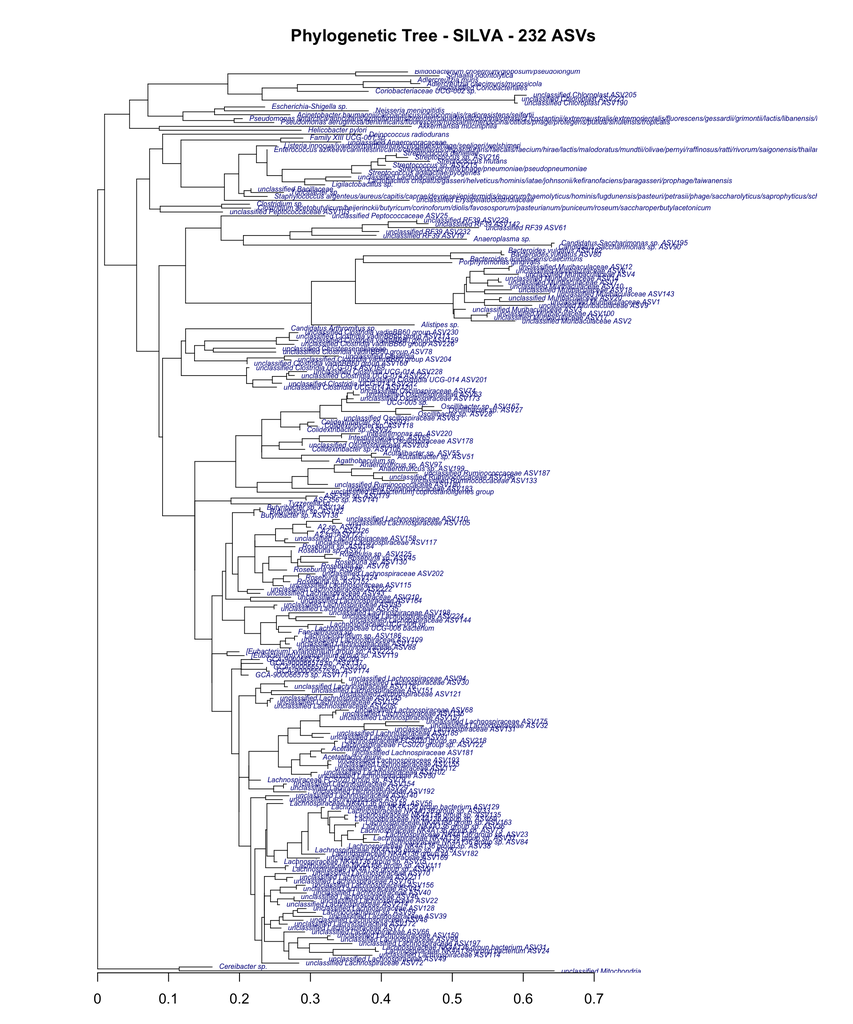

```
## Tree plot saved to: PROJECT_ROOT/example/run_results/6_phylogenetic_tree/phylogenetic_tree_GTDB.pdf
```

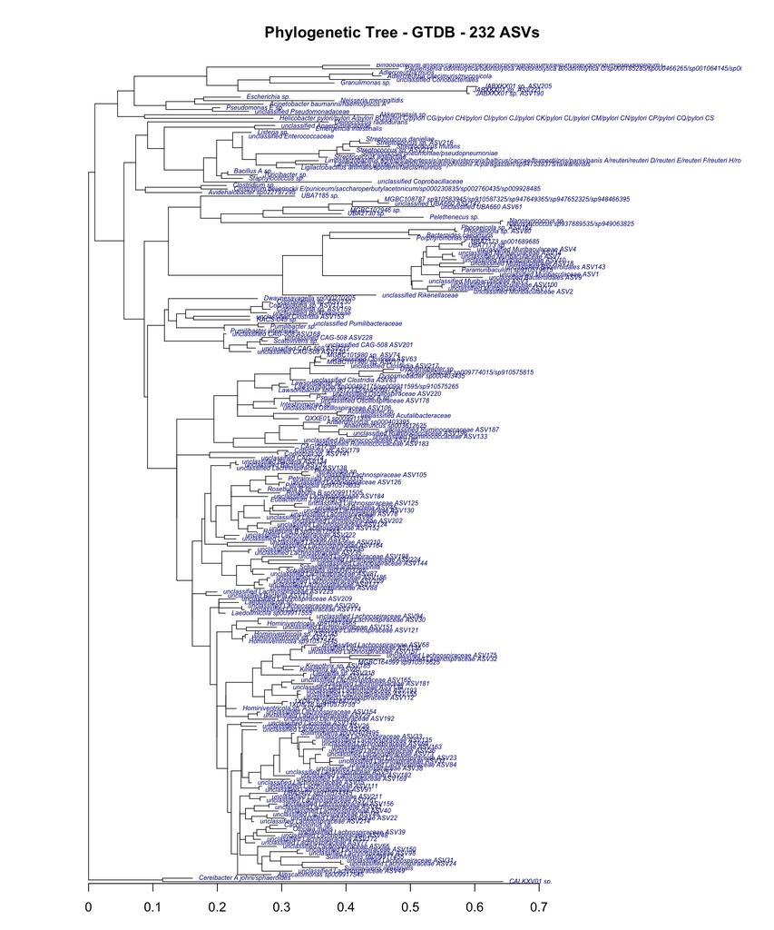

```r
if (tree_constructed) {
    local({

    n_tips <- length(phylo_tree$tip.label)

    # Space between a tip's branch endpoint and where its label text starts,
    # in the same distance units as the tree's branch lengths (substitutions
    # per site) -- scaled to the tree's total root-to-tip depth (rather than
    # a fixed value) so the gap looks proportional whether the tree is
    # shallow or deep. This is what keeps labels from sitting directly on
    # top of (and overlapping) the branch tip itself. plot.phylo() already
    # widens the plot's x-axis automatically to make room for the offset
    # label text, so this does not get clipped at the right edge.
    tree_depth <- max(node.depth.edgelength(phylo_tree))
    tip_label_offset <- tree_depth * 0.015

    # Bottom plot margin (in lines of text, the same unit par("mar") always
    # uses), trimmed down from R's session default of 5.1 lines so
    # axisPhylo()'s tick marks and labels sit close beneath the last tip's
    # branch instead of leaving a wide band of empty space -- while still
    # leaving enough room for the axis tick labels themselves not to be
    # clipped. Only the bottom margin is touched; left/top/right stay at
    # their defaults for the tip labels and main title. Captured once here
    # and restored after the loop below so it does not leak into later
    # chunks.
    default_plot_mar <- par("mar")
    tree_plot_mar <- c(3, default_plot_mar[2], default_plot_mar[3], default_plot_mar[4])

    # R's default plotting behaviour (par("yaxs") = "r", for "regular") pads
    # the y-axis by an extra 4% of the data range on *both* ends beyond
    # whatever y.lim a plot actually asks for -- and since ape::plot.phylo()
    # sets that range to exactly c(1, n_tips), 4% of it grows in lock-step
    # with the tree's own tip count. That is what was still leaving a large,
    # tree-size-dependent gap between the last tip and axisPhylo()'s tick
    # marks below even after the bottom-margin trim above: for a small
    # 10-tip tree 4% of the range is under a quarter of one tip-row, but for
    # a real several-hundred-tip amplicon tree it can add up to multiple
    # inches of empty space. yaxs = "i" ("internal") switches to using the
    # supplied y.lim exactly as given, with no automatic padding, so the gap
    # below is instead set explicitly and consistently via tree_plot_y_lim
    # just below, regardless of how many tips the tree has.
    default_plot_yaxs <- par("yaxs")
    on.exit(par(mar = default_plot_mar, yaxs = default_plot_yaxs), add = TRUE)

    # Explicit y-axis limits, padded by a fixed tree_plot_tip_row_padding
    # fraction of one tip-row (rather than a fraction of the whole tree's
    # tip count, as R's default padding does) on each end -- just enough
    # room for the top and bottom tip labels' own text height not to be
    # clipped by the plot's edges, without leaving a large gap above the
    # first tip or below the last one. Used with yaxs = "i" (set alongside
    # tree_plot_mar at each plot() call below) so this exact range is what
    # gets drawn, instead of R's usual 4%-of-range auto-padding.
    tree_plot_tip_row_padding <- 0.5
    tree_plot_y_lim <- c(1 - tree_plot_tip_row_padding, n_tips + tree_plot_tip_row_padding)

    # ape::plot.phylo() auto-computes x.lim (the horizontal data range shown,
    # including space reserved for tip label text) from the CURRENT tip
    # labels alone, separately for every plot -- so a database with much
    # longer Unique_Tax strings (e.g. GTDB's long addSpecies() candidate
    # lists) reserves more of the page for text and proportionally less for
    # the tree itself, making the SAME underlying branch lengths look more
    # compressed in that database's PDF than in a database with shorter
    # labels, even though phylo_tree's edge.length values never change
    # between databases (only the tip TEXT does) -- this is what was making
    # the SILVA and GTDB tree plots look like they had different branch
    # lengths side-by-side. To keep branch lengths visually comparable
    # across every generated PDF, x.lim is instead computed once here -- via
    # a throwaway plot to a null graphics device for every database's label
    # set -- and the widest resulting range is reused for every actual plot
    # below.
    pdf(NULL)
    tryCatch({
        x_max <- -Inf
        for (db_name in names(tip_labels_by_database)) {
            probe_tree <- phylo_tree
            probe_tree$tip.label <- unname(tip_labels_by_database[[db_name]])
            plot(probe_tree, type = "phylogram", cex = 0.6, label.offset = tip_label_offset)
            x_max <- max(x_max, get("last_plot.phylo", envir = ape::.PlotPhyloEnv)$x.lim[2])
        }
        shared_x_lim <- c(0, x_max)
    }, finally = {
        dev.off()
    })

    # Accumulated across the loop below and rendered once, after it, as a
    # plain top-level statement -- see "Format Taxonomy Tables" in Step 5
    # for why print()-ing this inside a for loop does not work: it bypasses
    # knitr's own asis-output dispatch and dumps the raw string as literal
    # text instead of a Markdown link.
    tree_plot_paths  <- character()
    tree_plot_labels <- character()

    for (db_name in names(tip_labels_by_database)) {

        cat("Generating tree visualization for", db_name, "...\n")

        # A separate, relabelled copy of the tree for just this database --
        # the original phylo_tree object (and the Newick file already
        # exported from it above) keep ASV_ID as their tip labels
        # throughout, which is what Step 9's taxa matching expects.
        phylo_tree_labeled <- phylo_tree
        phylo_tree_labeled$tip.label <- unname(tip_labels_by_database[[db_name]][phylo_tree_labeled$tip.label])

        # Tip labels are always shown, however many ASVs there are -- PDF
        # height scales with the number of tips so labels stay legible even
        # for the large ASV counts typical of a real amplicon run (this can
        # still make for a very tall PDF and a crowded inline plot with
        # hundreds of tips).
        tree_plot_path <- here(output_folder, paste0("phylogenetic_tree_", db_name, ".pdf"))

        pdf(tree_plot_path, width = 12, height = max(10, n_tips * 0.15))
        tryCatch({
            par(mar = tree_plot_mar, yaxs = "i")

            plot(phylo_tree_labeled,
                 type = "phylogram",
                 cex = 0.6,
                 edge.width = 1,
                 label.offset = tip_label_offset,
                 tip.color = "darkblue",
                 x.lim = shared_x_lim,
                 y.lim = tree_plot_y_lim,
                 main = paste("Phylogenetic Tree -", db_name, "-", n_tips, "ASVs"))

            axisPhylo(backward = FALSE)
        }, finally = {
            dev.off()
        })

        cat("Tree plot saved to:", tree_plot_path, "\n")

        tree_plot_paths  <- c(tree_plot_paths, tree_plot_path)
        tree_plot_labels <- c(tree_plot_labels, paste(db_name, "phylogenetic tree (PDF)\n"))

        # Also display in notebook -- one inline plot per database, each
        # captured separately by knitr as its own figure.
        par(mar = tree_plot_mar, yaxs = "i")
        plot(phylo_tree_labeled,
             type = "phylogram",
             cex = 0.5,
             edge.width = 0.8,
             label.offset = tip_label_offset,
             tip.color = "darkblue",
             x.lim = shared_x_lim,
             y.lim = tree_plot_y_lim,
             main = paste("Phylogenetic Tree -", db_name, "-", n_tips, "ASVs"))
        axisPhylo(backward = FALSE)
    }

    # Restore the session's default plot margin and y-axis padding mode so
    # neither leaks into later chunks (e.g. the Branch Length Distribution
    # ggplot below, which does not use par() itself but should not depend on
    # this chunk having left it altered).
    par(mar = default_plot_mar, yaxs = default_plot_yaxs)

    render_output_links(tree_plot_paths, labels = tree_plot_labels)
    })
}
```

- SILVA phylogenetic tree (PDF) : example/run_results/6_phylogenetic_tree/phylogenetic_tree_SILVA.pdf - GTDB phylogenetic tree (PDF) : example/run_results/6_phylogenetic_tree/phylogenetic_tree_GTDB.pdf

## 6.6 Visualize Interactively with iTOL

For interactive exploration and editing (zooming, panning, re-rooting, collapsing clades, recolouring by taxonomy, switching to a circular/unrooted layout, exporting a custom figure, and so on), upload one of the labelled Newick files from “Export Labeled Newick Files” above – phylogenetic_tree_SILVA_labeled.nwk and/or phylogenetic_tree_GTDB_labeled.nwk in results/6_phylogenetic_tree/ – to [iTOL](https://itol.embl.de/) (Interactive Tree Of Life), a free web-based tree viewer:

1. Go to https://itol.embl.de/upload.cgi.
2. Upload the labelled `.nwk` file for whichever database you want to explore (tips are already `Unique_Tax` values, so no separate ID-to-taxonomy lookup is needed).
3. Use iTOL’s controls to switch between rectangular/circular/unrooted layouts, change colours and label styles, collapse or prune clades, and export a publication-ready figure (SVG/PDF/PNG) directly from the browser.

An iTOL account is optional – an uploaded tree is viewable and editable immediately, though creating a free account lets you save and revisit trees later. This replaces this notebook’s previous built-in `ggtree` + `plotly` HTML widget, which is no longer generated. iTOL’s homepage: https://itol.embl.de/.

## 6.7 Branch Length Distribution

Visualize the distribution of branch lengths in the phylogenetic tree.

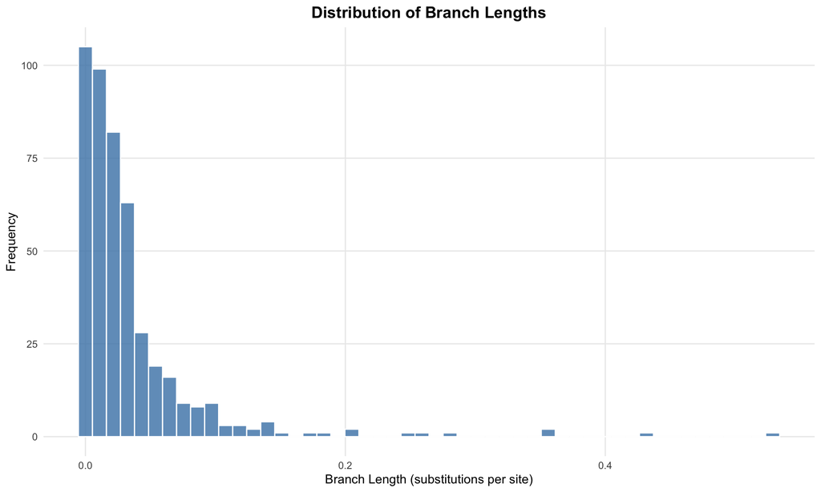

```
## Branch length distribution plot saved.
```

```r
if (tree_constructed) {

    # Create branch length histogram
    branch_lengths <- phylo_tree$edge.length

    branch_length_plot <- ggplot(data.frame(length = branch_lengths), aes(x = length)) +
        geom_histogram(bins = 50, fill = "steelblue", color = "white", alpha = 0.8) +
        theme_minimal() +
        labs(
            title = "Distribution of Branch Lengths",
            x = "Branch Length (substitutions per site)",
            y = "Frequency"
        ) +
        theme(
            plot.title = element_text(hjust = 0.5, size = 14, face = "bold"),
            panel.grid.minor = element_blank()
        )

    print(branch_length_plot)

    # Save plot
    ggsave(
        filename = here(output_folder, "branch_length_distribution.pdf"),
        plot = branch_length_plot,
        width = 10,
        height = 6
    )

    cat("Branch length distribution plot saved.\n")

    render_output_links(
        here(output_folder, "branch_length_distribution.pdf"),
        labels = "Branch length distribution (PDF)"
    )
}
```

- Branch length distribution (PDF): example/run_results/6_phylogenetic_tree/branch_length_distribution.pdf

# 7 Results Summary

## 7.1 Generate Summary Report

This chunk compiles the key inputs, durations, and results from every step above (alignment, tree construction) into a single processing summary table, exported to the Excel workbook alongside the more detailed statistics tables.

```r
# Compile processing summary
processing_summary <- data.frame(
    Step = c(
        "Input ASVs",
        "Alignment length",
        "Alignment duration",
        "Tree tips",
        "Tree construction duration",
        "Total branch length"
    ),
    Value = c(
        nrow(asv_sequences),
        ifelse(exists("sequence_alignment"), width(sequence_alignment)[1], NA),
        ifelse(exists("alignment_duration"),
               paste(round(as.numeric(alignment_duration), 2), "min"), NA),
        ifelse(tree_constructed, length(phylo_tree$tip.label), NA),
        ifelse(exists("tree_duration"),
               paste(round(as.numeric(tree_duration), 2), "min"), NA),
        ifelse(tree_constructed,
               round(sum(phylo_tree$edge.length), 4), NA)
    ),
    stringsAsFactors = FALSE
)

# Display summary -- kept in this long (one row per Step) shape for the
# console listing above, which stays readable regardless of how many steps
# there are; the Excel export just below transposes to one column per Step
# instead (see comment there for why).
cat("Processing summary:\n")
```

```
## Processing summary:
```

```
##    Input ASVs : 232
##    Alignment length : 260
##    Alignment duration : 0.02 min
##    Tree tips : 232
##    Tree construction duration : 0.02 min
##    Total branch length : 15.3574
```

```
## Sheet Processing_Summary added successfully to the workbook: PROJECT_ROOT/example/run_results/6_phylogenetic_tree/phylogenetic_tree_summary.xlsx
```

## 7.2 Document and Export Column Dictionary

Build a trailing `Column_Dictionary` sheet that documents every column of every sheet written to `output_excel_path` (`Alignment_Statistics`, `Tree_Statistics` when the tree was constructed, and `Processing_Summary`), so the workbook is self-describing without a hand-maintained description list that can drift out of sync with the data it documents.

- Phylogenetic tree processing summary (Excel workbook): example/run_results/6_phylogenetic_tree/phylogenetic_tree_summary.xlsx

# 8 Output File Summary

The tree below lists the files produced for the validated current run. Core alignment and rooted-tree outputs are always required; taxonomy-labelled outputs appear only for taxonomy tables that were present and validated during this run. Obsolete optional outputs are removed before regeneration so the listing cannot silently include products from an earlier database configuration.

```
## Final checkpoint saved: PROJECT_ROOT/example/run_results/6_phylogenetic_tree/checkpoints/checkpoint_final.rds
```

```
example/run_results/6_phylogenetic_tree/
├── alignment.fasta                      # Multiple sequence alignment (FASTA)
├── branch_length_distribution.pdf       # Branch length distribution (PDF)
├── checkpoints/
│   ├── checkpoint_1_alignment.rds
│   ├── checkpoint_2_tree.rds
│   └── checkpoint_final.rds
├── fasttree.log                         # FastTree diagnostic output (text)
├── phylogenetic_tree_GTDB_labeled.nwk   # Phylogenetic tree, GTDB Unique_Tax tip labels (Newick) -- upload to iTOL
├── phylogenetic_tree_GTDB.pdf           # GTDB phylogenetic tree (PDF)
├── phylogenetic_tree_SILVA_labeled.nwk  # Phylogenetic tree, SILVA Unique_Tax tip labels (Newick) -- upload to iTOL
├── phylogenetic_tree_SILVA.pdf          # SILVA phylogenetic tree (PDF)
├── phylogenetic_tree_summary.xlsx       # Phylogenetic tree processing summary (Excel workbook)
└── phylogenetic_tree.nwk                # Phylogenetic tree, ASV_ID tip labels (Newick)
```

# 9 Recommended Next Step

The alignment and phylogenetic tree exported above are ready to be incorporated into the rest of the pipeline. Proceed to [Step 9 — Phyloseq Object Assembly](https://github.com/changlabs/DADA2_16S_Illumina_PairedEnd_Workflow/blob/main/R/notebooks/9_phyloseq_object.md), which automatically detects and imports this notebook’s tree results/6_phylogenetic_tree/phylogenetic_tree.nwk if present – alongside the ASV count table(s) and taxonomy from Step 5 (and, optionally, Steps 7-8) – to build the final, annotated `phyloseq` object(s). Including the tree there is what enables UniFrac distances and phylogenetic diversity metrics in downstream analysis; if you skipped this notebook, Step 9 still builds its phyloseq object(s) without a tree, with no error.

# 10 Session Information

# 11 References

## 11.1 Methods

- Wright ES (2016). Using DECIPHER v2.0 to Analyze Big Biological Sequence Data in R. *The R Journal*, 8(1), 352-359. https://journal.r-project.org/archive/2016/RJ-2016-025/index.html (provides `AlignSeqs()`, the profile-to-profile multiple sequence alignment algorithm used above)
- Price MN, Dehal PS, Arkin AP (2010). FastTree 2 – Approximately Maximum-Likelihood Trees for Large Alignments. *PLoS ONE*, 5(3):e9490. https://doi.org/10.1371/journal.pone.0009490
- Paradis E, Schliep K (2019). ape 5.0: an environment for modern phylogenetics and evolutionary analyses in R. *Bioinformatics*, 35(3), 526-528. https://doi.org/10.1093/bioinformatics/bty633 (provides tree import and the tree statistics and static plots computed above)
- Letunic I, Bork P (2021). Interactive Tree Of Life (iTOL) v5: an online tool for phylogenetic tree display and annotation. *Nucleic Acids Research*, 49(W1), W293-W296. https://doi.org/10.1093/nar/gkab301 (the recommended tool for interactively exploring and editing this notebook’s labelled Newick files – see Visualize Interactively with iTOL above)
- Lozupone C, Knight R (2005). UniFrac: a New Phylogenetic Method for Comparing Microbial Communities. *Applied and Environmental Microbiology*, 71(12), 8228-8235. https://doi.org/10.1128/AEM.71.12.8228-8235.2005 (the tree exported by this notebook is the phylogenetic input UniFrac distance calculations require downstream)
- Faith DP (1992). Conservation Evaluation and Phylogenetic Diversity. *Biological Conservation*, 61(1), 1-10. https://doi.org/10.1016/0006-3207(92)91201-3 (defines the phylogenetic diversity metric this notebook’s tree also enables downstream)

## 11.2 Related

- [Step 5 — DADA2 Pipeline](https://github.com/changlabs/DADA2_16S_Illumina_PairedEnd_Workflow/blob/main/R/notebooks/5_dada2_pipeline.md) – this notebook’s required input.
- [Step 9 — Phyloseq Object Assembly](https://github.com/changlabs/DADA2_16S_Illumina_PairedEnd_Workflow/blob/main/R/notebooks/9_phyloseq_object.md) – this notebook’s recommended next step, which incorporates the tree if present.

# 12 Appendix: Troubleshooting Guide

## 12.1 Understanding the Output

### 12.1.1 Alignment File (FASTA)

- Contains all ASV sequences aligned to a common coordinate system
- Gaps (-) indicate insertions/deletions relative to other sequences
- Used as input for phylogenetic tree construction

### 12.1.2 Tree File (Newick)

- Standard format for phylogenetic trees
- Contains topology and branch lengths
- Can be loaded into tree visualization software (iTOL, FigTree, ggtree)
- Branch lengths represent expected substitutions per site

### 12.1.3 Tree Statistics

- **Total branch length**: Sum of all edge lengths; higher values indicate more evolutionary diversity
- **Mean branch length**: Average evolutionary distance between nodes
- **Binary tree**: A tree where each internal node has exactly two descendants

## 12.2 Common Issues and Solutions

### 12.2.1 Project-local FastTree Not Found

**Error**: `The project-local FastTree executable is missing or not executable`

**Solutions**:

- On Linux, rerun setup/install_required_tools.R. It installs the workflow-controlled executable at tools/fasttree/FastTree.
- Verify that the local file exists and has execute permission. Step 6 intentionally does not fall back to a system-wide executable.

### 12.2.2 Memory Issues During Alignment

**Error**: Cannot allocate memory during DECIPHER alignment

**Possible causes**:

- Too many sequences for available RAM
- Sequences are very long

**Solutions**:

- Reduce the number of sequences (subsample if necessary)
- Increase system memory or use a machine with more RAM
- Consider using an alternative aligner like MAFFT for very large datasets

### 12.2.3 Tree Construction Fails

**Error**: Tree file not created or is empty

**Possible causes**:

- Invalid alignment file
- FastTreeMP execution failed
- Insufficient disk space

**Solutions**:

- Verify the alignment file exists and is not empty
- Run FastTreeMP manually from the command line to see error messages
- Check disk space availability

### 12.2.4 ASV Sequences File Not Found

**Error**: `ASV sequences file not found`

**Solutions**:

- Ensure Step 5 (DADA2 Pipeline) has been completed
- Check the path in dada2_results_folder
- Verify the file is named asv_sequences.csv